# TidyVerse CREATE Assignment

Jian Quan Chen

2023-03-27

In this assignment, you’ll practice collaborating around a code project with GitHub. You could consider our collective work as building out a book of examples on how to use TidyVerse functions.

GitHub repository: https://github.com/acatlin/SPRING2023TIDYVERSE

FiveThirtyEight.com datasets.

Kaggle datasets.

Your task here is to Create an Example. Using one or more TidyVerse packages, and any dataset from fivethirtyeight.com or Kaggle, create a programming sample “vignette” that demonstrates how to use one or more of the capabilities of the selected TidyVerse package with your selected dataset. (25 points)

Later, you’ll be asked to extend an existing vignette. Using one of your classmate’s examples (as created above), you’ll then extend his or her example with additional annotated code. (15 points)

You should clone the provided repository. Once you have code to submit, you should make a pull request on the shared repository. You should also update the README.md file with your example.

After you’ve created your vignette, please submit your GitHub handle name in the submission link provided below. This will let your instructor know that your work is ready to be peer-graded.

You should complete your submission on the schedule stated in the course syllabus.

# Introduction

For this assignment, I will be creating a programming sample vignette to demonstrate the use of the `tidyr` package in the tidyverse package. I will be working with the “Video Game Sales” (https://www.kaggle.com/datasets/gregorut/videogamesales) data set from Kaggle. The data set was generated by a scrape of vgchartz.com and contains the sales of video games that sold greater than 100,000 copies from 1980 to 2020.

The `tidyr` package provides a set of functions that help tidy data, an important in the data wrangling process. Ideally, in a tidy data set, each column should correspond to a single variable while each row should represent a single observation and each cell contains a single value.

In the “Video Game Sales” dataset, the sales are presented in a wide format in which the sales of countries are split into multiple columns. In order to tidy this data, I will be using the `pivot_longer` function from the `tidyr` package to reshape these columns into one single column. Then, analyzing the data to identify which region and which genre had the most video game sales.

# Code

## Importing Library

```r
library(tidyverse)
```

## Importing the Dataset

```r
video_games_df <- read.csv("https://raw.githubusercontent.com/LeJQC/MSDS/main/DATA%20607/TidyVerse%20CREATE%20Assignment/vgsales.csv")
glimpse(video_games_df)
```

```
## Rows: 16,598
## Columns: 11
## $ Rank         <int> 1, 2, 3, 4, 5, 6, 7, 8, 9, 10, 11, 12, 13, 14, 15, 16, 17…
## $ Name         <chr> "Wii Sports", "Super Mario Bros.", "Mario Kart Wii", "Wii…
## $ Platform     <chr> "Wii", "NES", "Wii", "Wii", "GB", "GB", "DS", "Wii", "Wii…
## $ Year         <chr> "2006", "1985", "2008", "2009", "1996", "1989", "2006", "…
## $ Genre        <chr> "Sports", "Platform", "Racing", "Sports", "Role-Playing",…
## $ Publisher    <chr> "Nintendo", "Nintendo", "Nintendo", "Nintendo", "Nintendo…
## $ NA_Sales     <dbl> 41.49, 29.08, 15.85, 15.75, 11.27, 23.20, 11.38, 14.03, 1…
## $ EU_Sales     <dbl> 29.02, 3.58, 12.88, 11.01, 8.89, 2.26, 9.23, 9.20, 7.06, …
## $ JP_Sales     <dbl> 3.77, 6.81, 3.79, 3.28, 10.22, 4.22, 6.50, 2.93, 4.70, 0.…
## $ Other_Sales  <dbl> 8.46, 0.77, 3.31, 2.96, 1.00, 0.58, 2.90, 2.85, 2.26, 0.4…
## $ Global_Sales <dbl> 82.74, 40.24, 35.82, 33.00, 31.37, 30.26, 30.01, 29.02, 2…
```

## Reshaping Data Frame to Long Format

The sales from each region can be combined into one single column using `pivot_longer`.

```r
sales_df <- video_games_df %>%
  pivot_longer(
    cols = NA_Sales:Other_Sales,
    names_to = "Region",
    names_pattern = "(.*)_[A-Za-z]*",
    values_to = "Sales",
    values_drop_na = TRUE
  )
glimpse(sales_df)
```

```
## Rows: 66,392
## Columns: 9
## $ Rank         <int> 1, 1, 1, 1, 2, 2, 2, 2, 3, 3, 3, 3, 4, 4, 4, 4, 5, 5, 5, …
## $ Name         <chr> "Wii Sports", "Wii Sports", "Wii Sports", "Wii Sports", "…
## $ Platform     <chr> "Wii", "Wii", "Wii", "Wii", "NES", "NES", "NES", "NES", "…
## $ Year         <chr> "2006", "2006", "2006", "2006", "1985", "1985", "1985", "…
## $ Genre        <chr> "Sports", "Sports", "Sports", "Sports", "Platform", "Plat…
## $ Publisher    <chr> "Nintendo", "Nintendo", "Nintendo", "Nintendo", "Nintendo…
## $ Global_Sales <dbl> 82.74, 82.74, 82.74, 82.74, 40.24, 40.24, 40.24, 40.24, 3…
## $ Region       <chr> "NA", "EU", "JP", "Other", "NA", "EU", "JP", "Other", "NA…
## $ Sales        <dbl> 41.49, 29.02, 3.77, 8.46, 29.08, 3.58, 6.81, 0.77, 15.85,…
```

## Analyzing the Sales Data

### Sum of Sales by Region

```r
sales_df %>%
  group_by(Region) %>%
  summarize(total_sales = sum(Sales)) %>%
  arrange(desc(total_sales))
```

```
## # A tibble: 4 × 2
##   Region total_sales
##   <chr>        <dbl>
## 1 NA           4393.
## 2 EU           2434.
## 3 JP           1291.
## 4 Other         798.
```

### Plotting Sales by Region

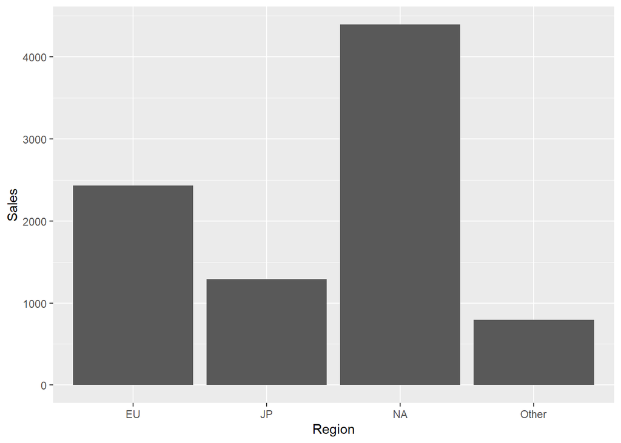

```r
sales_df %>%
  ggplot(aes(x=Region, y= Sales))+
  geom_bar(stat = "identity")
```

### Most Popular Genres

```r
sales_df %>%
  group_by(Genre) %>%
  summarise(count = n()) %>%
  mutate(percent = round(count/sum(count)*100)) %>%
  arrange(desc(count))
```

```
## # A tibble: 12 × 3
##    Genre        count percent
##    <chr>        <int>   <dbl>
##  1 Action       13264      20
##  2 Sports        9384      14
##  3 Misc          6956      10
##  4 Role-Playing  5952       9
##  5 Shooter       5240       8
##  6 Adventure     5144       8
##  7 Racing        4996       8
##  8 Platform      3544       5
##  9 Simulation    3468       5
## 10 Fighting      3392       5
## 11 Strategy      2724       4
## 12 Puzzle        2328       4
```

### Sales by Genre

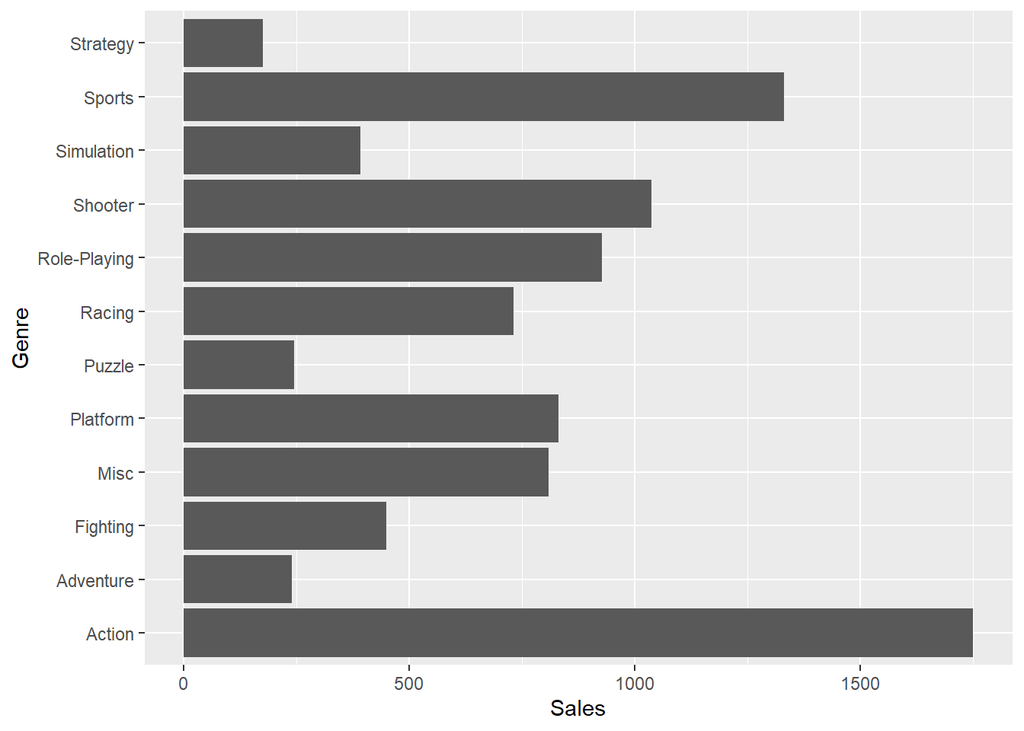

```r
sales_df %>%
  group_by(Genre) %>%
  ggplot((aes(x = Genre,y = Sales)))+
  geom_bar(stat = "identity")+
  coord_flip()
```

## Reshaping Data Frame back to Wide Format

Sometimes, the wide format of a dataset presents a better visualization of the data, which can make it easier to understand. For that, there is a `pivot_wider` function. This function is the inverse of `pivot_longer` and converts one column into multiple columns.

```r
# Has the same amount of variables and observations as the starting data frame
sales_wide <- sales_df %>%
  pivot_wider(
    names_from = "Region",
    values_from = "Sales")
glimpse(sales_wide)
```

```
## Rows: 16,598
## Columns: 11
## $ Rank         <int> 1, 2, 3, 4, 5, 6, 7, 8, 9, 10, 11, 12, 13, 14, 15, 16, 17…
## $ Name         <chr> "Wii Sports", "Super Mario Bros.", "Mario Kart Wii", "Wii…
## $ Platform     <chr> "Wii", "NES", "Wii", "Wii", "GB", "GB", "DS", "Wii", "Wii…
## $ Year         <chr> "2006", "1985", "2008", "2009", "1996", "1989", "2006", "…
## $ Genre        <chr> "Sports", "Platform", "Racing", "Sports", "Role-Playing",…
## $ Publisher    <chr> "Nintendo", "Nintendo", "Nintendo", "Nintendo", "Nintendo…
## $ Global_Sales <dbl> 82.74, 40.24, 35.82, 33.00, 31.37, 30.26, 30.01, 29.02, 2…
## $ `NA`         <dbl> 41.49, 29.08, 15.85, 15.75, 11.27, 23.20, 11.38, 14.03, 1…
## $ EU           <dbl> 29.02, 3.58, 12.88, 11.01, 8.89, 2.26, 9.23, 9.20, 7.06, …
## $ JP           <dbl> 3.77, 6.81, 3.79, 3.28, 10.22, 4.22, 6.50, 2.93, 4.70, 0.…
## $ Other        <dbl> 8.46, 0.77, 3.31, 2.96, 1.00, 0.58, 2.90, 2.85, 2.26, 0.4…
```

```r
glimpse(video_games_df)
```

```
## Rows: 16,598
## Columns: 11
## $ Rank         <int> 1, 2, 3, 4, 5, 6, 7, 8, 9, 10, 11, 12, 13, 14, 15, 16, 17…
## $ Name         <chr> "Wii Sports", "Super Mario Bros.", "Mario Kart Wii", "Wii…
## $ Platform     <chr> "Wii", "NES", "Wii", "Wii", "GB", "GB", "DS", "Wii", "Wii…
## $ Year         <chr> "2006", "1985", "2008", "2009", "1996", "1989", "2006", "…
## $ Genre        <chr> "Sports", "Platform", "Racing", "Sports", "Role-Playing",…
## $ Publisher    <chr> "Nintendo", "Nintendo", "Nintendo", "Nintendo", "Nintendo…
## $ NA_Sales     <dbl> 41.49, 29.08, 15.85, 15.75, 11.27, 23.20, 11.38, 14.03, 1…
## $ EU_Sales     <dbl> 29.02, 3.58, 12.88, 11.01, 8.89, 2.26, 9.23, 9.20, 7.06, …
## $ JP_Sales     <dbl> 3.77, 6.81, 3.79, 3.28, 10.22, 4.22, 6.50, 2.93, 4.70, 0.…
## $ Other_Sales  <dbl> 8.46, 0.77, 3.31, 2.96, 1.00, 0.58, 2.90, 2.85, 2.26, 0.4…
## $ Global_Sales <dbl> 82.74, 40.24, 35.82, 33.00, 31.37, 30.26, 30.01, 29.02, 2…
```